# Loudon

Topics that will be discussed in this summary report for Loudon County are

- Demographic Characteristics
  - Population growth from 1970 to 2020;
  - population density
  - sex, race, and age
  - educational level of the adult population
  - housing characteristics in terms of age of the housing stock and type of tenure
- Economic Characteristics
  - family income, household income, per capita income,
  - poverty status of families;
  - employment classification according to industry;
  - labor force by place of work and commuting patterns;

For more details on the data used, please see the Data Description tab.

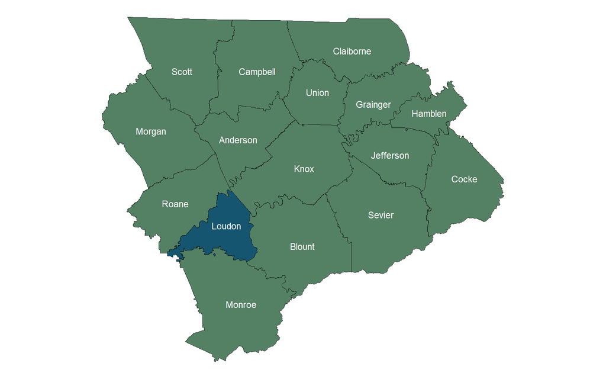

**Population and Growth**

| Place | 1970 | 1980 | 1990 | 2000 | 2010 | 2020 | Change 1970-1980 | Change 1980-1990 | Change 1990-2000 | Change 2000-2010 | Change 2010-2020 |
| --- | --- | --- | --- | --- | --- | --- | --- | --- | --- | --- | --- |
| Loudon County | 24266 | 28553 | 31255 | 39086 | 48556 | 54886 | 4287 | 2702 | 7831 | 9470 | 6330 |
| Greenback |  | 546 | 611 | 954 | 1064 | 1102 |  | 65 | 343 | 110 | 38 |
| Lenoir City | 5324 | 5446 | 6147 | 6819 | 8642 | 10117 | 122 | 701 | 672 | 1823 | 1475 |
| Loudon | 3728 | 3943 | 4026 | 4476 | 5381 | 5991 | 215 | 83 | 450 | 905 | 610 |
| Philadelphia |  | 507 | 463 | 533 | 656 | 607 |  | -44 | 70 | 123 | -49 |

[interactive chart not shown]

IPUMS NHGIS, University of Minnesota, www.nhgis.org

**Population Density**

| Place | Area | Population Density |
| --- | --- | --- |
| Loudon County | 247.3456582229722 | 221.8999936943404 |
| Greenback | 8.451936828532812 | 130.3843157321963 |
| Lenoir City | 8.395053727375112 | 1205.114383843651 |
| Loudon | 13.04745330474008 | 459.1700663778958 |
| Philadelphia | 1.554954361009881 | 390.3651549012524 |

[interactive chart not shown]

source: U. S. Census Bureau *Decennial Census: Redistricting Data (PL 94-171)*, 2020, accessed June 2, 2026, http://api.census.gov/data/2020/dec/pl.

**Population Descriptions**

| Place | Year | Race Category | Number of People | Percentage of People |
| --- | --- | --- | --- | --- |
| Loudon County | 2020 | Black | 584 | 0.008032680907252796 |
| Loudon County | 2020 | Other | 6949 | 0.0955806500419515 |
| Loudon County | 2020 | White | 47353 | 0.6513211284266124 |
| Greenback | 2020 | Black | 5 | 6.877295297305476e-05 |
| Greenback | 2020 | Other | 64 | 0.0008802937980551009 |
| Greenback | 2020 | White | 1033 | 0.01420849208423311 |
| Lenoir City | 2020 | Black | 135 | 0.001856869730272478 |
| Lenoir City | 2020 | Other | 2458 | 0.03380878368155372 |
| Lenoir City | 2020 | White | 7524 | 0.1034895396338528 |
| Loudon | 2020 | Black | 142 | 0.001953151864434755 |

[output cut: 5 more lines]

| Place | Sex | Age Range | Year | Number of People | Percentage of People |
| --- | --- | --- | --- | --- | --- |
| Loudon County | Female | 10 to 14 years | 2020 | 1740 | 0.02477573686458778 |
| Loudon County | Female | 15 to 19 years | 2020 | 1308 | 0.0186245194361384 |
| Loudon County | Female | 20 to 24 years | 2020 | 1364 | 0.01942189947315962 |
| Loudon County | Female | 25 to 29 years | 2020 | 1220 | 0.01737149366367649 |
| Loudon County | Female | 30 to 34 years | 2020 | 1200 | 0.01708671507902606 |
| Loudon County | Female | 35 to 39 years | 2020 | 1585 | 0.02256870283354692 |
| Loudon County | Female | 40 to 44 years | 2020 | 1283 | 0.01826854620532536 |
| Loudon County | Female | 45 to 49 years | 2020 | 1740 | 0.02477573686458778 |
| Loudon County | Female | 5 to 9 years | 2020 | 1155 | 0.01644596326356258 |
| Loudon County | Female | 50 to 54 years | 2020 | 1696 | 0.02414922397835683 |

[output cut: 170 more lines]

[interactive chart not shown]

source: U. S. Census Bureau *Decennial Census: Redistricting Data (PL 94-171)*, 2020, accessed June 2, 2026, http://api.census.gov/data/2020/dec/pl.

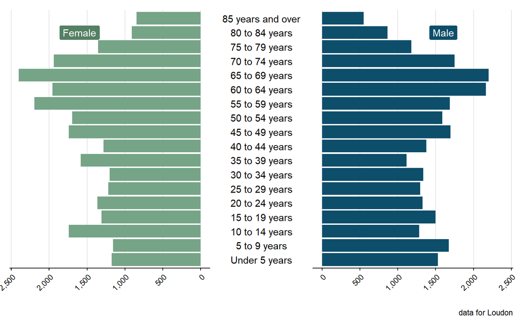

source: U. S. Census Bureau *American Community Survey 5-Year Estimates: Comparison Profiles 5-Year*, 2020, accessed June 2, 2026, http://api.census.gov/data/2020/acs/acs5.

**Education**

| Place | Level of Education | Year | Number of People | Percentage of People |
| --- | --- | --- | --- | --- |
| Loudon County | 9th to 12th Grade, No Diploma | 2010 | 2297 | 0.05713361854541837 |
| Loudon County | Associate's degree | 2010 | 2197 | 0.05464630385036315 |
| Loudon County | Bachelor's degree | 2010 | 5242 | 0.1303850363147946 |
| Loudon County | Graduate or Professional Degree | 2010 | 2452 | 0.06098895632275395 |
| Loudon County | Less Than 9th Grade | 2010 | 2418 | 0.06014326932643518 |
| Loudon County | Some College, No Degree | 2010 | 7274 | 0.1809272709183166 |
| Loudon County | Total | 2010 | 34061 | 0.8472042582827579 |
| Loudon County | 9th to 12th Grade, No Diploma | 2020 | 2661 | 0.05208149844401386 |
| Loudon County | Associate's degree | 2020 | 3057 | 0.05983207092948153 |
| Loudon County | Bachelor's degree | 2020 | 7003 | 0.1370637856457832 |

[output cut: 53 more lines]

[interactive chart not shown]

source: U. S. Census Bureau *American Community Survey 5-Year Estimates: Comparison Profiles 5-Year*, 2020, accessed June 2, 2026, http://api.census.gov/data/2020/acs/acs5.

**Housing Units by Year of Construction**

| Place | Year | 1939 or earlier | 1940-1959 | 1960-1979 | 1980 to 1989 | 1990 to 1999 | 2000 to 2004 | 2005 or later | 2000 to 2009 | 2010 or later | Total |
| --- | --- | --- | --- | --- | --- | --- | --- | --- | --- | --- | --- |
| Loudon County | 2010 | 1783 | 2711 | 3778 | 3006 | 5792 | 2472 | 1478 |  |  | 21020 |
| Loudon County | 2020 | 1898 | 2594 | 4328 | 2591 | 4467 |  |  | 5100 | 2415 | 23393 |
| Greenback | 2010 | 90 | 90 | 103 | 59 | 104 | 21 | 0 |  |  | 467 |
| Lenoir City | 2010 | 846 | 936 | 504 | 505 | 584 | 261 | 138 |  |  | 3774 |
| Philadelphia | 2010 | 46 | 70 | 44 | 15 | 43 | 18 | 17 |  |  | 253 |
| Greenback | 2020 | 53 | 60 | 125 | 21 | 87 |  |  | 70 | 10 | 426 |
| Lenoir City | 2020 | 767 | 446 | 604 | 539 | 406 |  |  | 781 | 637 | 4180 |
| Loudon | 2020 | 310 | 582 | 676 | 146 | 248 |  |  | 344 | 103 | 2409 |
| Philadelphia | 2020 | 95 | 34 | 44 | 16 | 51 |  |  | 36 | 34 | 310 |

[interactive chart not shown]

source: U. S. Census Bureau *Decennial Census: Redistricting Data (PL 94-171)*, 2020, accessed June 2, 2026, http://api.census.gov/data/2020/dec/pl.

**Housing Units by Type of Tenure**

| Place | Year | Own | Rent | Total |
| --- | --- | --- | --- | --- |
| Loudon County | 2010 | 15149 | 4292 | 19441 |
| Loudon County | 2020 | 16625 | 4342 | 20967 |
| Greenback | 2010 | 297 | 81 | 378 |
| Lenoir City | 2010 | 1906 | 1517 | 3423 |
| Philadelphia | 2010 | 161 | 35 | 196 |
| Greenback | 2020 | 271 | 77 | 348 |
| Lenoir City | 2020 | 2113 | 1602 | 3715 |
| Loudon | 2020 | 1332 | 845 | 2177 |
| Philadelphia | 2020 | 201 | 51 | 252 |

[interactive chart not shown]

source: U. S. Census Bureau *Decennial Census: Redistricting Data (PL 94-171)*, 2020, accessed June 2, 2026, http://api.census.gov/data/2020/dec/pl.

**Income Comparison**

| Place | Year | Median Family Income | Median Household Income | Per Capita Income |
| --- | --- | --- | --- | --- |
| Loudon County | 2020 | 74247 | 61664 | 34158 |
| Greenback | 2020 | 83036 | 74107 | 25948 |
| Lenoir City | 2020 | 60511 | 45987 | 24828 |
| Loudon | 2020 | 62193 | 46148 | 27384 |
| Philadelphia | 2020 | 75833 | 70500 | 25656 |

[interactive chart not shown]

source: U. S. Census Bureau *Decennial Census: Redistricting Data (PL 94-171)*, 2020, accessed June 2, 2026, http://api.census.gov/data/2020/dec/pl.

**Povery Status**

| Place | Year | Above Poverty | Below Poverty |
| --- | --- | --- | --- |
| Loudon County | 2020 | 13439 | 1389 |
| Greenback | 2020 | 260 | 3 |
| Lenoir City | 2020 | 1965 | 353 |
| Loudon | 2020 | 1259 | 113 |
| Philadelphia | 2020 | 180 | 10 |

[interactive chart not shown]

source: U. S. Census Bureau *American Community Survey 5-Year Estimates: Comparison Profiles 5-Year*, 2020, accessed June 2, 2026, http://api.census.gov/data/2020/acs/acs5.

**Poverty Status by Family Type**

| Place | Poverty Status | Family Type | Number of Families | Year | Percentage of Families |
| --- | --- | --- | --- | --- | --- |
| Loudon County | Above Poverty | All Families | 13439 | 2020 | 0.7083970270412735 |
| Loudon County | Above Poverty | Female Householder | 982 | 2020 | 0.05176321754256497 |
| Loudon County | Above Poverty | Female Householder with related children | 308 | 2020 | 0.01623530652047863 |
| Loudon County | Below Poverty | All Families | 1389 | 2020 | 0.07321701544462601 |
| Loudon County | Below Poverty | Female Householder | 493 | 2020 | 0.02598703283959728 |
| Loudon County | Below Poverty | Female Householder with related children | 411 | 2020 | 0.02166464603869063 |
| Greenback | Above Poverty | All Families | 260 | 2020 | 0.01370512888092352 |
| Greenback | Above Poverty | Female Householder | 35 | 2020 | 0.001844921195508935 |
| Greenback | Above Poverty | Female Householder with related children | 20 | 2020 | 0.001054240683147963 |
| Greenback | Below Poverty | All Families | 3 | 2020 | 0.0001581361024721944 |

[output cut: 20 more lines]

[interactive chart not shown]

source: U. S. Census Bureau *American Community Survey 5-Year Estimates: Comparison Profiles 5-Year*, 2020, accessed June 2, 2026, http://api.census.gov/data/2020/acs/acs5.

**Employment by Industry**

| Place | Industry | Year | Number of Jobs | Percentage of Jobs |
| --- | --- | --- | --- | --- |
| Greenback | Arts, Entertainment, And Recreation, And Accommodation And Food Services | 2010 | 83 | 0.1800433839479393 |
| Greenback | Arts, Entertainment, And Recreation, And Accommodation And Food Services | 2020 | 11 | 0.002624671916010499 |
| Greenback | Educational Services, And Health Care And Social Assistance | 2010 | 75 | 0.1626898047722343 |
| Greenback | Educational Services, And Health Care And Social Assistance | 2020 | 121 | 0.02887139107611549 |
| Greenback | Manufacturing | 2010 | 67 | 0.1453362255965293 |
| Greenback | Manufacturing | 2020 | 87 | 0.02075876879026485 |
| Greenback | Other Industries | 2010 | 178 | 0.386117136659436 |
| Greenback | Other Industries | 2020 | 234 | 0.05583392984967788 |
| Greenback | Professional, Scientific, And Management, And Administrative, And Waste Management Services | 2020 | 36 | 0.06679035250463822 |
| Greenback | Retail Trade | 2010 | 58 | 0.1258134490238612 |

[output cut: 50 more lines]

[interactive chart not shown]

source: U. S. Census Bureau *American Community Survey 5-Year Estimates: Comparison Profiles 5-Year*, 2020, accessed June 2, 2026, http://api.census.gov/data/2020/acs/acs5.

**Employment by Industry (Historical)**

| Place | Year | Industry | Number of Jobs | Percentage of Jobs |
| --- | --- | --- | --- | --- |
| Greenback | 2010 | Agriculture, Forestry, Fishing And Hunting, And Mining | 7 | 0.0002901915264074289 |
| Greenback | 2010 | Construction | 41 | 0.001699693226100655 |
| Greenback | 2010 | Manufacturing | 67 | 0.002777547467042534 |
| Greenback | 2010 | Other | 18 | 0.0007462067821905314 |
| Greenback | 2010 | Professional Services | 193 | 0.008000994942376254 |
| Greenback | 2010 | Public Administration | 17 | 0.0007047508498466131 |
| Greenback | 2010 | Trade, Finance, Insurance &amp; Real Estate | 118 | 0.004891800016582373 |
| Greenback | 2020 | Agriculture, Forestry, Fishing And Hunting, And Mining | 3 | 9.778675967274031e-05 |
| Greenback | 2020 | Construction | 65 | 0.002118713126242707 |
| Greenback | 2020 | Manufacturing | 87 | 0.002835816030509469 |

[output cut: 83 more lines]

**Labor Force by Place of Work**

| Place | Year | Work Out Of State | Work Out of County of Residence | Work in County of Residence |
| --- | --- | --- | --- | --- |
| Loudon County | 2020 | 263 | 11030 | 11452 |
| Greenback | 2020 | 14 | 403 | 118 |
| Lenoir City | 2020 | 79 | 2147 | 1937 |
| Loudon | 2020 | 11 | 810 | 1700 |
| Philadelphia | 2020 | 3 | 146 | 214 |

[interactive chart not shown]

source: U. S. Census Bureau *American Community Survey 5-Year Estimates: Comparison Profiles 5-Year*, 2020, accessed June 2, 2026, http://api.census.gov/data/2020/acs/acs5.

**Commuting Patterns**

| Home County | Year | Number of Jobs | Percentage of Jobs |
| --- | --- | --- | --- |
| Loudon | 2010 | 5810 | 0.1949010399194901 |
| Loudon | 2020 | 5548 | 0.1861120429386112 |
| Knox | 2020 | 2721 | 0.09127809459912781 |
| Knox | 2010 | 2064 | 0.06923851056692384 |
| Monroe | 2020 | 1660 | 0.0556860114055686 |
| Monroe | 2010 | 1482 | 0.04971486078497148 |
| Blount | 2020 | 1325 | 0.04444817175444481 |
| Blount | 2010 | 973 | 0.032640053673264 |
| Anderson | 2020 | 434 | 0.01455887286145589 |
| Anderson | 2010 | 291 | 0.009761824890976182 |

[output cut: 3 more lines]

| Work County | Year | Number of Jobs | Percentage of Jobs |
| --- | --- | --- | --- |
| Knox | 2020 | 6413 | 0.2151291512915129 |
| Loudon | 2010 | 5810 | 0.1949010399194901 |
| Loudon | 2020 | 5548 | 0.1861120429386112 |
| Knox | 2010 | 5521 | 0.1852063066085206 |
| Blount | 2020 | 1840 | 0.06172425360617242 |
| Monroe | 2020 | 1268 | 0.04253606172425361 |
| Blount | 2010 | 1233 | 0.04136195907413619 |
| Monroe | 2010 | 802 | 0.02690372358269037 |
| Roane | 2020 | 393 | 0.01318349547131835 |
| Roane | 2010 | 289 | 0.009694733310969473 |

[output cut: 3 more lines]

[interactive chart not shown]

source: U. S. Census Bureau *Tn_od_main_JT00_2020*, LEHD Origin-Destination Employment Statistics, 8.3, 2020, accessed June 2, 2026, https://lehd.ces.census.gov/data/lodes/.

## References

Bureau, U. S. Census. *American Community Survey 5-Year Estimates: Comparison Profiles 5-Year*. 2020. Accessed June 2, 2026. http://api.census.gov/data/2020/acs/acs5.

Bureau, U. S. Census. *Decennial Census: Redistricting Data (PL 94-171)*. 2020. Accessed June 2, 2026. http://api.census.gov/data/2020/dec/pl.

Bureau, U. S. Census. *Tn_od_main_JT00_2020*. LEHD Origin-Destination Employment Statistics, 8.3. 2020. Accessed June 2, 2026. https://lehd.ces.census.gov/data/lodes/.